# Why Do EDA

MCC

I was discussing Data Science with a Journalist the other day, and a question came up, Why are Boxplots important with respect to Exploratory Data Analysis? Boxplots and Histograms are the first tools taught when learning statistical software, but why? Many online-courses (I’ve seen) gloss over the “WHY.”

> For more on Exploratory Data Analysis, I recommend [Exploratory Data Analysis with R](https://leanpub.com/exdata) by Roger Peng. Even if you don’t use R (yet) it has some nuggets.

Since this discussion started with a journalist co-worker, I was reminded of the 5 W’s of reporting:

1. Who
2. What
3. When
4. Where
5. Why
- How might a journalist think of the five W’s when analyzing a dataset.
- Can these five questions be useful when carrying out a Data Analysis?

In short, **Yes**.

**And**, I believe the five W’s should be asked by Data Scientists too.

- **Why** is this data being analyzed?
  - Are we hypothesis testing?
  - Are we looking for a correlation or a regression line?
  - Is the data normally distributed?
- **When** and **Where** was the data collected?
  - If a political poll is asked in 2 cities, is it reasonable to assume that the entire country will poll the same way?
  - Could the time of day? day of the week? or season of the year change the data collected?
- **Who** gathered this data?
  - Is it important what prejudices that person or group had collecting the data?
- And finally, **What** can be learned from the dataset?

What do these examples of asking the five W’s have in common? In my mind, they all dive deep into the story or (in this case) the data.

Commonly, one of the first topics discussed in statistics classes is the concept of bias.

> Bias - Inclined to one side; swelled on one side; an inclination; to give a particular direction to; to influence; to prejudice; to prepossess.

> Webster, 1913

## What is wrong with your data?

Even for a scientist, the five W’s are a good means to focus your skepticism. In the world of scientific research, many people think about the simplest example to study. This is the reductionist approach. But what happens when political polls are asked of a number of people in one city or two cities. Can that poll be generalized to include everyone in that county, state and country?

- What is wrong with the data?
- Is there anything wrong with your study?
- Is it possible to fix the study or data?
- Can we as Data Scientists understand where biases are introduced?

Exploratory Data Analysis is the first review of your data and information.

In my mind, EDA is a first attempt to investigate what is right and wrong with your dataset.

In general there are five types types of statistical bias to avoid.

1. Sampling Bias
2. Bias in Assignment
3. Omitted Variables
4. Self-Serving Bias
5. Experimenter Expectations

> In an unbiased random sample, every case in the population should have an equal likelihood of being part of the sample.

> Jenny Gutbezahl, [HBS Online](https://online.hbs.edu/blog/post/types-of-statistical-bias)

#### Sampling Bias

If we think of a political poll, the study should have about the same fraction (percent, proportion, ratio) of college educated vs non-college educated volunteers.

##### Bias in Assignment

Assignment bias can also be called selection bias.

An example of this could be that you are a teacher. You ask for volunteers to check the spelling or grammar of several papers. Ask your yourself, will the teacher find the students with the average grammar or spelling skills? Probably not. In most studies the ‘volunteers’ are themselves chosen from select groups that have a similar ratio English majors as Chemistry majors as in the school population.

Jeff Leek and Roger Peng have an interesting view of Data Science in the article, ‘What is the Question?’[^1]

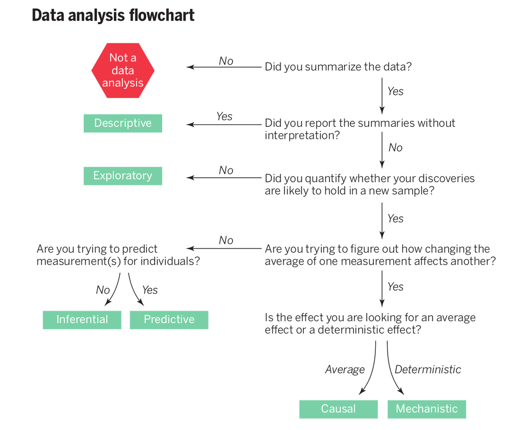

In the flowchart above, Data Science and Statistics can be broken down into 6 categories. In this piece, I will be focusing on Exploratory Data Analysis (EDA).

> Perturbation, in mathematics, a method for solving a problem by comparing it with a similar one for which the solution is known. Usually the solution found in this way is only approximate.

> https://www.britannica.com/science/perturbation-mathematics

But first, let us prepare some good and bad data.

#### Generate a dataset

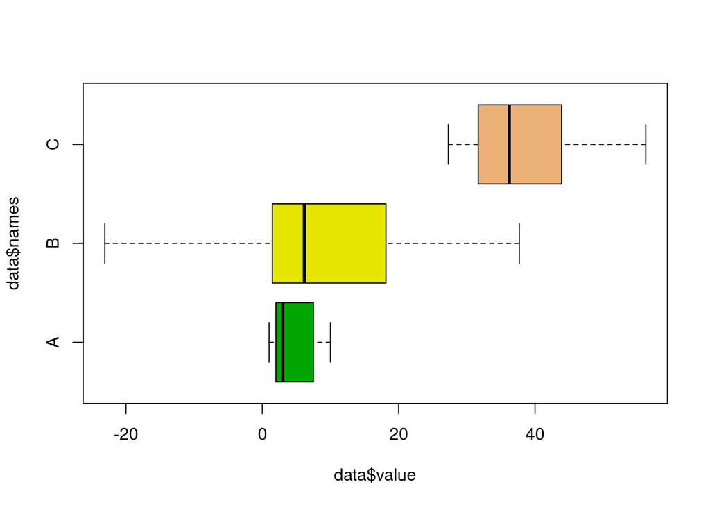

```r
# Create data
names <- c(rep("A", 15) , rep("B", 15) , rep("C", 15))
value <- c( rpois(15, 5) , rnorm(15, mean=10, sd=15) , rnorm(15, mean=40, sd=10) )
data <- data.frame(names,value)

boxplot(data$value ~ data$names , col=terrain.colors(4), horizontal = T )
```

Square Values

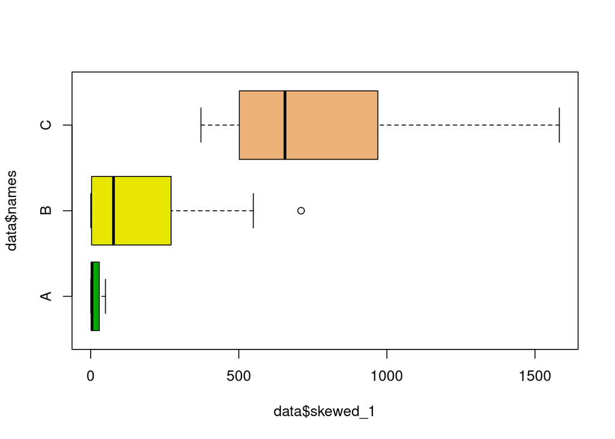

```r
skewed_1 = (1/2)*(data$value)^2
data <- cbind(data, skewed_1)

boxplot(data$skewed_1 ~ data$names , col=terrain.colors(4), horizontal = T )
```

https://statisticsglobe.com/jitter-r-function-example/ https://stackoverflow.com/questions/23675735/how-to-add-boxplots-to-scatterplot-with-jitter https://www.data-to-viz.com/caveat/boxplot.html

[^1]: Science, 20 MARCH 2015, VOL 347, ISSUE 6228, P. 1314